# Tuango - Targeting Mobile App Messages

```python
import numpy as np
import pandas as pd
import polars as pl
import pyrsm as rsm
import seaborn as sns

# you can import additional python packages but only use packages that
# are already part of the docker container
```

```python
# check that you have version 0.9.10 of pyrsm or newer
rsm.__version__
```

```
'0.9.18'
```

```python
# Use this dataset and notebook to answer questions 1-13
tuango = pd.read_parquet("data/tuango_post.parquet")
```

```python
tuango.drop_duplicates()
tuango.isnull().sum()
```

```
userid            0
buyer             0
ordersize         0
recency           0
frequency         0
monetary          0
age               0
gender            0
music             0
training     397252
test              0
dtype: int64
```

```python
tuango.head(10)
```

|  | userid | buyer | ordersize | recency | frequency | monetary | age | gender | music | training | test |
| --- | --- | --- | --- | --- | --- | --- | --- | --- | --- | --- | --- |
| 0 | U15889344 | no | 0.0 | 309 | 7.0 | 39.799999 | 44 | F | yes | 0.0 | 1 |
| 1 | U60246497 | no | 0.0 | 297 | 8.0 | 39.799999 | 80 | M | yes | 1.0 | 1 |
| 2 | U22965759 | no | 0.0 | 295 | 1.0 | 72.900002 | 59 | F | yes | 1.0 | 1 |
| 3 | U40811142 | no | 0.0 | 277 | 1.0 | 40.000000 | 37 | F | yes | 0.0 | 1 |
| 4 | U76283952 | no | 0.0 | 259 | 1.0 | 21.000000 | 43 | F | yes | 1.0 | 1 |
| 5 | U37412566 | no | 0.0 | 243 | 1.0 | 19.900000 | 19 | M | yes | 1.0 | 1 |
| 6 | U45474095 | no | 0.0 | 216 | 1.0 | 40.000000 | 38 | F | yes | 1.0 | 1 |
| 7 | U15371036 | no | 0.0 | 213 | 3.0 | 40.000000 | 49 | F | yes | 0.0 | 1 |
| 8 | U79932394 | yes | 4.0 | 212 | 1.0 | 19.900000 | 59 | F | yes | 1.0 | 1 |
| 9 | U84213856 | no | 0.0 | 208 | 1.0 | 63.799999 | 85 | F | yes | 1.0 | 1 |

```python
rsm.md("data/tuango_post_description.md")
```

Tuango: Targeting Mobile App Push Messages

This file has the roll-out results. There are no missing values for `buyer` and `ordersize`. The other variables are the same as in the pre dataset.

Variable Names and Descriptions

- userid: Unique user ID

**Response to the customized push message**

- buyer: Did the customer buy the Karaoke deal? ("yes" or "no")

- ordersize: Number of 30-minute Karaoke sessions the customer purchased

**Recency, Frequency, and Monetary variables**

- recency: Days since last purchase of a deal (before the Karaoke deal offer)

- frequency: Number of deals purchased during the one year period before the Karaoke deal offer

- monetary: Average amount spent per order (in RMB) during the one year period before the Karaoke deal offer

**Other variables in the dataset**

- age: Age of the customer

- gender: Gender identity of the customer (M = male, F = female, O = Other or unknown)

- music: Customer made a purchase in the music category during the one-year period before the Karaoke deal offer ("no" or "yes")

- test: Splits the dataset into test (1) and rollout (0) data

- training: Splits the dataset into training (1) and test (0) data. This variable will not be used in this assignment

```python
tuango.dtypes
```

```
userid         object
buyer        category
ordersize     float64
recency         int32
frequency     float64
monetary      float64
age             int32
gender       category
music        category
training      float64
test            int32
dtype: object
```

```python
tuango["gender"] = np.where(tuango["gender"] == "M", 1, np.where(tuango["gender"] == "F", 0, np.nan))

tuango["music"] = np.where(tuango["music"] == "yes", 1, np.where(tuango["buyer"] == "no", 0, np.nan))
```

```python
tuango.dtypes
```

```
userid         object
buyer        category
ordersize     float64
recency         int32
frequency     float64
monetary      float64
age             int32
gender        float64
music         float64
training      float64
test            int32
dtype: object
```

```python
# (i.e., there are missing values in the data that you will need to deal with)
tuango.dropna(inplace=True)
# Move this code to a cell after cell index 9
tuango["buyer"].value_counts(dropna=False)
```

```
buyer
no     17898
yes     1573
Name: count, dtype: int64
```

```python
# you will likely find the below useful in this assignment
tuango.buyer.isna().value_counts()
```

```
buyer
False    19471
Name: count, dtype: int64
```

```python
# create a variable called 'buyer_yes' that has value 1 when buyer == 'yes', has value 0 when buyer == 'no' and has value np.nan when pd.isna(buyer) is True

tuango["buyer_yes"] = np.where(tuango["buyer"] == "yes", 1, np.where(tuango["buyer"] == "no", 0, np.nan))

tuango.buyer_yes.value_counts(dropna=False)
```

```
buyer_yes
0.0    17898
1.0     1573
Name: count, dtype: int64
```

```python
tuango.isnull().sum()
```

```
userid       0
buyer        0
ordersize    0
recency      0
frequency    0
monetary     0
age          0
gender       0
music        0
training     0
test         0
buyer_yes    0
dtype: int64
```

```python
tuango.shape
```

```
(19471, 12)
```

## Part I: Preliminary Analysis

### Question 1

What percentage of customers responded to the deal offer message (i.e., bought the deal)?

```python
# insert calculation code here
# the result should be expressed as a percentage as a string with 2 decimal
# places and assigned to q1 (e.g., q1 = '5.43%')

q1 = tuango[tuango.test==1].groupby("buyer", observed=False).buyer.agg(n_obs="count")
q1["perc"] = (q1 / q1.sum()).round(4) #.astype(str) + "%"
q1
```

| buyer | n_obs | perc |
| --- | --- | --- |
| yes | 1573 | 0.0808 |
| no | 17898 | 0.9192 |

### Question 2

What was the average number of sessions purchased by customers that bought one or more 30-minute sessions? Use the ordersize variable for your calculation.

Create a pivot table with count, mean and std. deviation of `ordersize` by `buyer`

```python
# insert calculation code here to create a pd.pivot_table that shows
# (1) counts the number of yes and no, (2) the mean ordersize, and
# (3) the standard deviation in ordersize for yes and no responses
q2 = pd.pivot_table(
    tuango[tuango.test==1],
    index="buyer",
    values=["ordersize"],  # Include "ordersize" as a column
    aggfunc={"ordersize":["count",  "mean",  "std"]}
).round(3)

# the below should show your result
# do not apply any rounding to your answer
# q2.loc["yes", ("ordersize", "mean")]
q2
```

| buyer | ordersize count | ordersize mean | ordersize std |
| --- | --- | --- | --- |
| yes | 1573 | 3.944 | 1.7 |
| no | 17898 | 0.000 | 0.0 |

## Part II: Building Targeting Models

### Question 3

Estimate a logistic regression model using buyer as the dependent variable (target) and, recency, frequency, monetary, age, gender, and music as the explanatory variables (features)

```python
lr = rsm.model.logistic(
    data={"tuango": tuango[tuango.test==1]},
    rvar="buyer",
    lev="yes",
    evar=["recency","frequency","monetary","age","gender","music"]
)
lr.summary()
```

```
Logistic regression (GLM)
Data                 : tuango
Response variable    : buyer
Level                : yes
Explanatory variables: recency, frequency, monetary, age, gender, music
Null hyp.: There is no effect of x on buyer
Alt. hyp.: There is an effect of x on buyer

                     OR                OR%  coefficient  std.error  z.value p.value
Intercept  0.000000e+00            -100.0%       -28.15  12707.570   -0.002   0.998
recency    9.990000e-01              -0.1%        -0.00      0.000   -2.949   0.003   **
frequency  1.111000e+00              11.1%         0.11      0.012    9.148  < .001  ***
monetary   1.002000e+00               0.2%         0.00      0.000   10.414  < .001  ***
age        9.870000e-01              -1.3%        -0.01      0.002   -8.513  < .001  ***
gender     4.810000e-01             -51.9%        -0.73      0.063  -11.593  < .001  ***
music      3.149685e+11  31496850579402.9%        26.48  12707.570    0.002   0.998

Signif. codes:  0 '***' 0.001 '**' 0.01 '*' 0.05 '.' 0.1 ' ' 1

Pseudo R-squared (McFadden): 0.141
Pseudo R-squared (McFadden adjusted): 0.139
Area under the RO Curve (AUC): 0.757
Log-likelihood: -4697.301, AIC: 9408.602, BIC: 9463.739
Chi-squared: 1535.905, df(6), p.value < 0.001
Nr obs: 19,471
```

```python
lr.summary(main=False,fit=True)
```

```
Pseudo R-squared (McFadden): 0.141
Pseudo R-squared (McFadden adjusted): 0.139
Area under the RO Curve (AUC): 0.757
Log-likelihood: -4697.301, AIC: 9408.602, BIC: 9463.739
Chi-squared: 1535.905, df(6), p.value < 0.001
Nr obs: 19,471
```

### Question 4

Create Prediction plots for all explanatory variables. Describe the effect of each explanatory variable on the probability that a customer will purchase the karaoke deal

[figure not shown]

```python
lr.plot("vimp") #, data=tuango[tuango.test==1])
```

### Question 5

Use Permutation Importance to assess variable importance. Which variables seem to be most important in the model?

music: This variable has the largest bar in the plot, indicating that it has the highest importance in the model. The model's predictive performance drops the most when the 'music' variable is permuted, suggesting that whether a customer is interested in music is a strong predictor of whether they will purchase the karaoke deal.

gender: The second longest bar signifies that gender also has a considerable impact on the model's predictions, although less so than 'music'.

age: This variable is moderately important in predicting the purchase of the karaoke deal, as indicated by the middle-range bar length.

monetary: The 'monetary' variable, which likely represents some monetary aspect of customer behavior, has a smaller but still noticeable effect on the model's predictions.

frequency: Frequency of past purchases shows some importance in the model, although it has a smaller impact compared to the variables listed above.

recency: The smallest bar for 'recency' suggests that the time since the last purchase has the least impact on the prediction of whether a customer will purchase the karaoke deal according to this model.

In summary, the 'music' and 'gender' variables appear to be the most important in predicting whether a customer will respond to the karaoke deal offer, according to the permutation importance plot.

### Question 6

Add the predicted values from the logistic regression to the "tuango" DataFrame. Use "pred_logit" as the variable name. Compare the average of the predicted values to the overall response rate (i.e., percentage of buyers). What do you notice when you do this calculation using only the data used to estimate the model? Explain.

[figure not shown]

```python
lr.plot("pred") #, excl=["gender", "music"], fix=(0.08, 0.21))
```

```python
from sklearn.linear_model import LogisticRegression
import pandas as pd

# Assuming 'tuango' is your DataFrame and it's already loaded
# Replace 'X_columns' with the list of column names you used as predictors
X_columns = ['recency', 'frequency', 'monetary', 'age', 'gender', 'music']
X = tuango[X_columns]
y = tuango['buyer_yes']  # Assuming 'purchase' is the column indicating if a purchase was made

# Initialize and fit the logistic regression model
logit_model = LogisticRegression()
logit_model.fit(X, y)

# Predict probabilities and add them to the DataFrame
tuango['pred_logit'] = logit_model.predict_proba(X)[:, 1]

# Compare the average of predicted values to the overall response rate
average_predicted = tuango['pred_logit'].mean()
overall_response_rate = y.mean()

print("Average Predicted Probability:", average_predicted)
print("Overall Response Rate:", overall_response_rate)
```

```
Average Predicted Probability: 0.08078617050141187
Overall Response Rate: 0.0807868111550511
```

```python
tuango.head()
```

|  | userid | buyer | ordersize | recency | frequency | monetary | age | gender | music | training | test | buyer_yes | pred_logit |
| --- | --- | --- | --- | --- | --- | --- | --- | --- | --- | --- | --- | --- | --- |
| 0 | U15889344 | no | 0.0 | 309 | 7.0 | 39.799999 | 44 | 0.0 | 1.0 | 0.0 | 1 | 0.0 | 0.145876 |
| 1 | U60246497 | no | 0.0 | 297 | 8.0 | 39.799999 | 80 | 1.0 | 1.0 | 1.0 | 1 | 0.0 | 0.054243 |
| 2 | U22965759 | no | 0.0 | 295 | 1.0 | 72.900002 | 59 | 0.0 | 1.0 | 1.0 | 1 | 0.0 | 0.075285 |
| 3 | U40811142 | no | 0.0 | 277 | 1.0 | 40.000000 | 37 | 0.0 | 1.0 | 0.0 | 1 | 0.0 | 0.093546 |
| 4 | U76283952 | no | 0.0 | 259 | 1.0 | 21.000000 | 43 | 0.0 | 1.0 | 1.0 | 1 | 0.0 | 0.085078 |

### Question 7

Estimate a linear regression model using "ordersize" as the response variable and recency, frequency, monetary, age, gender, and music as the explanatory variables. Estimate this regression using only those customers who placed an order after the deal offer message. Describe why you think it does (not) make sense to focus on this group of customers.

```python
# Define the ordersize variable
ordersize = tuango["ordersize"]

# Perform regression analysis
reg = rsm.regress({"buyer": tuango}, rvar="ordersize", evar=["recency", "frequency", "monetary", "age"])
```

```python
reg.summary(

)
```

```
Linear regression (OLS)
Data                 : buyer
Response variable    : ordersize
Explanatory variables: recency, frequency, monetary, age
Null hyp.: the effect of x on ordersize is zero
Alt. hyp.: the effect of x on ordersize is not zero

           coefficient  std.error  t.value p.value
Intercept        0.320      0.027   12.066  < .001  ***
recency         -0.000      0.000   -2.466   0.014    *
frequency        0.035      0.004    8.929  < .001  ***
monetary         0.001      0.000   12.806  < .001  ***
age             -0.003      0.000   -7.412  < .001  ***

Signif. codes:  0 '***' 0.001 '**' 0.01 '*' 0.05 '.' 0.1 ' ' 1

R-squared: 0.015, Adjusted R-squared: 0.015
F-statistic: 74.667 df(4, 19466), p.value < 0.001
Nr obs: 19,471
```

```python
tuango
```

|  | userid | buyer | ordersize | recency | frequency | monetary | age | gender | music | training | test | buyer_yes | pred_logit |
| --- | --- | --- | --- | --- | --- | --- | --- | --- | --- | --- | --- | --- | --- |
| 0 | U15889344 | no | 0.0 | 309 | 7.0 | 39.799999 | 44 | 0.0 | 1.0 | 0.0 | 1 | 0.0 | 0.145876 |
| 1 | U60246497 | no | 0.0 | 297 | 8.0 | 39.799999 | 80 | 1.0 | 1.0 | 1.0 | 1 | 0.0 | 0.054243 |
| 2 | U22965759 | no | 0.0 | 295 | 1.0 | 72.900002 | 59 | 0.0 | 1.0 | 1.0 | 1 | 0.0 | 0.075285 |
| 3 | U40811142 | no | 0.0 | 277 | 1.0 | 40.000000 | 37 | 0.0 | 1.0 | 0.0 | 1 | 0.0 | 0.093546 |
| 4 | U76283952 | no | 0.0 | 259 | 1.0 | 21.000000 | 43 | 0.0 | 1.0 | 1.0 | 1 | 0.0 | 0.085078 |
| ... | ... | ... | ... | ... | ... | ... | ... | ... | ... | ... | ... | ... | ... |
| 20902 | U36788134 | yes | 7.0 | 125 | 2.0 | 330.360000 | 34 | 0.0 | 1.0 | 0.0 | 1 | 1.0 | 0.214633 |
| 20903 | U20475633 | no | 0.0 | 118 | 4.0 | 18.710001 | 73 | 0.0 | 0.0 | 1.0 | 1 | 0.0 | 0.000688 |
| 20904 | U51354565 | no | 0.0 | 118 | 3.0 | 92.450000 | 38 | 0.0 | 1.0 | 1.0 | 1 | 0.0 | 0.143941 |
| 20905 | U69360423 | no | 0.0 | 117 | 4.0 | 51.140000 | 30 | 0.0 | 1.0 | 0.0 | 1 | 0.0 | 0.159144 |
| 20906 | U48889214 | no | 0.0 | 117 | 4.0 | 162.110006 | 42 | 0.0 | 0.0 | 1.0 | 1 | 0.0 | 0.001446 |

19471 rows × 13 columns

### Question 8

Use Permutation Importance to assess variable importance. Which variables seem to be most important in the model?

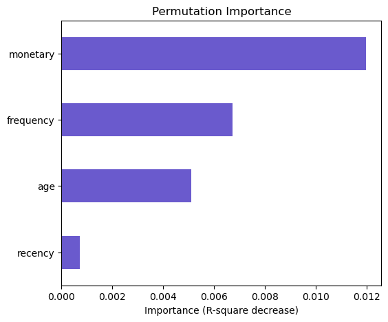

```python
reg.plot("vimp")
```

### Question 9

What do the linear regression model results suggest about our ability to predict ordersize for customers who responded to the deal?

R-squared (0.015): This value indicates that only 1.5% of the variability in ordersize can be explained by the model. This is a very low value, suggesting that the model does not have strong predictive power.

Adjusted R-squared (0.015): This adjusted metric also indicates a very low explanatory power of the model, taking into account the number of predictors used. Since it's very close to the R-squared value, it suggests that the number of variables is not inflating the explanatory power of the model significantly.

F-statistic (74.667): The F-statistic is significant with a p-value less than 0.001, indicating that the model as a whole is statistically significant. This means that while the explanatory power is low, the variables included in the model collectively have a statistically significant effect on ordersize.

Permutation Importance Plot: The plot shows the importance of each variable based on the decrease in R-squared when that variable is randomly shuffled. The variable monetary appears to have the highest importance, followed by frequency, age, and recency having the least importance. This suggests that monetary is the most significant predictor among the variables included.

Number of Observations (19,471): The large number of observations provides a solid base for the model, which means that the low R-squared is not due to a lack of data.

### Question 10

Add the predicted values from the linear regression to the "tuango" data.frame. Compare the average of the predicted values to the average value of ordersize. Make sure to focus only on buyers. What do you notice?

```python
import pandas as pd
import statsmodels.api as sm

# Load your DataFrame here
# tuango = pd.read_csv("path/to/your/tuango.csv")  # Replace with the correct path to your data

# Assuming the DataFrame 'tuango' has been loaded and the following columns exist:
# 'buyer' indicates whether a customer bought the deal or not (1 for yes, 0 for no)
# 'ordersize' indicates the number of 30-minute sessions purchased
# Other columns like 'recency', 'frequency', 'monetary', 'age', 'gender', 'music' exist

# Filter the DataFrame to include only buyers
buyers = tuango[tuango['buyer'] == 1]

# Define the predictor variables and the response variable
predictors = ['recency', 'frequency', 'monetary', 'age', 'gender', 'music']
X = tuango[predictors]
X = sm.add_constant(X)  # Adds a constant term to the predictors
y = tuango['ordersize']

# Fit the linear regression model
model = sm.OLS(y, X).fit()

# Add the predicted values to the 'tuango' DataFrame for buyers only
tuango['predicted_ordersize'] = model.predict(X)

# Calculate the average predicted order size and compare it to the actual average order size
avg_pred_ordersize = tuango['predicted_ordersize'].mean()
avg_actual_ordersize = tuango['ordersize'].mean()

print(f"Average Predicted Order Size for Buyers: {avg_pred_ordersize}")
print(f"Average Actual Order Size for Buyers: {avg_actual_ordersize}")
```

```
Average Predicted Order Size for Buyers: 0.31862770273740426
Average Actual Order Size for Buyers: 0.3186277027374044
```

```python
tuango.head()
```

|  | userid | buyer | ordersize | recency | frequency | monetary | age | gender | music | training | test | buyer_yes | pred_logit | predicted_ordersize |
| --- | --- | --- | --- | --- | --- | --- | --- | --- | --- | --- | --- | --- | --- | --- |
| 0 | U15889344 | no | 0.0 | 309 | 7.0 | 39.799999 | 44 | 0.0 | 1.0 | 0.0 | 1 | 0.0 | 0.145876 | 0.565724 |
| 1 | U60246497 | no | 0.0 | 297 | 8.0 | 39.799999 | 80 | 1.0 | 1.0 | 1.0 | 1 | 0.0 | 0.054243 | 0.289370 |
| 2 | U22965759 | no | 0.0 | 295 | 1.0 | 72.900002 | 59 | 0.0 | 1.0 | 1.0 | 1 | 0.0 | 0.075285 | 0.346877 |
| 3 | U40811142 | no | 0.0 | 277 | 1.0 | 40.000000 | 37 | 0.0 | 1.0 | 0.0 | 1 | 0.0 | 0.093546 | 0.392454 |
| 4 | U76283952 | no | 0.0 | 259 | 1.0 | 21.000000 | 43 | 0.0 | 1.0 | 1.0 | 1 | 0.0 | 0.085078 | 0.358439 |